# Project 1 - Classification

## CS (STAT) 5525 Due - April 1, 2021

## Instructions and Experiments

Note: Please read the entire project description before you begin. The goal of this project is to analyze the performance of classification algorithms on several synthetic and real-world data sets. This will be done in the following steps:

- First, you will explore the data sets.
- Next, you will perform a series of experiments on which you will be asked to answer a series of questions. For these experiments, you will be running a Python Jupyter notebook.
- Third, you will compile your answers in the form of a report.

## Python Jupyter Notebooks

We recommend installing Jupyter using Anaconda as it will also install other regularly used packages for scientific computing and data science. Some pointers to setup Jupyter notebooks on your system:

- Video link - https://www.youtube.com/watch?v=MvN7Wdh0Juk
- Medium Link - https://medium.com/@neuralnets/beginners-quick-guide-for-handling-issues-launching-jupyter-notebook-for-python-using-anaconda-8be3d57a209b
- Tutorials link - https://www.dataquest.io/blog/jupyter-notebook-tutorial/, https://www.youtube.com/watch?v=3C9E2yPBw7s 1

## Before you Begin

- Visually explore the data sets in the experiments below, and consider the following:
  - Types of attributes
  - Class distribution
  - Which attributes appear to be good predictors, if any
  - Possible correlation between attributes
  - Any special structure that you might observe - Note: The discussion of this exploration is not required in the report, but this step will help you get ready to answer the questions that follow
- Use precision and recall as evaluation metrics to report classification performance.
- Your goal is to learn everything that you can about the dataset. Answer the questions below as a starting point, but you should dig further. What more can you discover? The goal of this assignment is to give a helping hand for you to discover the most interesting and surprising things. Report and Submission
- Write a report addressing the experiment questions. Your project will be evaluated based only on what you write on the report. Submit the report as a PDF file on Canvas.
- Collect output from all your experiments and submit your Jupyter notebooks (cells displaying output) electronically as a separate zipped file on Canvas. We will look at your outputs if something is ambiguous in your report. Copy and paste the output from the Jupyter notebook into your report only to the limited extent needed to support your answers.

## 1 Problem 1 [37 points]

The files for this problem are under the Experiment 1 folder. Datasets to be used for experimentation: telecom churn.csv. Jupyter notebook to use as a starting point: Exploratory data analysis.ipynb. In this experiment, we will do exploratory data analysis to get a better sense of data. The dataset contains record of telecom customer along with the label "churn". Churn = "true" signifies that the customer has left the company and churn = "false" signifies that the customer is still loyal to the company. Answer the following questions

```python
import pandas as pd
df = pd.read_csv('Experiment_-_1/telecom_churn.csv')
df.head()
```

|  | state | account length | area code | phone number | international plan | voice mail plan | number vmail messages | total day minutes | total day calls | total day charge | ... | total eve calls | total eve charge | total night minutes | total night calls | total night charge | total intl minutes | total intl calls | total intl charge | customer service calls | churn |
| --- | --- | --- | --- | --- | --- | --- | --- | --- | --- | --- | --- | --- | --- | --- | --- | --- | --- | --- | --- | --- | --- |
| 0 | KS | 128 | 415 | 382-4657 | no | yes | 25 | 265.1 | 110 | 45.07 | ... | 99 | 16.78 | 244.7 | 91 | 11.01 | 10.0 | 3 | 2.70 | 1 | False |
| 1 | OH | 107 | 415 | 371-7191 | no | yes | 26 | 161.6 | 123 | 27.47 | ... | 103 | 16.62 | 254.4 | 103 | 11.45 | 13.7 | 3 | 3.70 | 1 | False |
| 2 | NJ | 137 | 415 | 358-1921 | no | no | 0 | 243.4 | 114 | 41.38 | ... | 110 | 10.30 | 162.6 | 104 | 7.32 | 12.2 | 5 | 3.29 | 0 | False |
| 3 | OH | 84 | 408 | 375-9999 | yes | no | 0 | 299.4 | 71 | 50.90 | ... | 88 | 5.26 | 196.9 | 89 | 8.86 | 6.6 | 7 | 1.78 | 2 | False |
| 4 | OK | 75 | 415 | 330-6626 | yes | no | 0 | 166.7 | 113 | 28.34 | ... | 122 | 12.61 | 186.9 | 121 | 8.41 | 10.1 | 3 | 2.73 | 3 | False |

5 rows × 21 columns

# 1. How many records are there in the dataset?

```python
len(df)
```

```
3333
```

```python
df.shape[0]
```

```
3333
```

**There are 3333 records in the dataset.**

# 2. How many input features are there for classification? Name each feature and assign it as categorical, count, or continuous.

```python
df.shape[1]
```

```
21
```

**The above output is the combination of input and target features, to eliminate the target feature "churn" below step is performed.**

```python
f = (df.shape[1]-1)
```

```python
len(df.columns[:f])
```

```
20
```

**There are 20 input features.**

```python
df.columns[:f]
```

```
Index(['state', 'account length', 'area code', 'phone number',
       'international plan', 'voice mail plan', 'number vmail messages',
       'total day minutes', 'total day calls', 'total day charge',
       'total eve minutes', 'total eve calls', 'total eve charge',
       'total night minutes', 'total night calls', 'total night charge',
       'total intl minutes', 'total intl calls', 'total intl charge',
       'customer service calls'],
      dtype='object')
```

**Above are the input features named.**

```python
df.dtypes
```

```
state                      object
account length              int64
area code                   int64
phone number               object
international plan         object
voice mail plan            object
number vmail messages       int64
total day minutes         float64
total day calls             int64
total day charge          float64
total eve minutes         float64
total eve calls             int64
total eve charge          float64
total night minutes       float64
total night calls           int64
total night charge        float64
total intl minutes        float64
total intl calls            int64
total intl charge         float64
customer service calls      int64
churn                        bool
dtype: object
```

```python
df_cat=df.select_dtypes(include='object')
print("Categorical features are :")
print(df_cat.columns)
```

```
Categorical features are :
Index(['state', 'phone number', 'international plan', 'voice mail plan'], dtype='object')
```

```python
df_cont=df.select_dtypes(include='float64')
print("Continuous features are :")
print(df_cont.columns)
```

```
Continuous features are :
Index(['total day minutes', 'total day charge', 'total eve minutes',
       'total eve charge', 'total night minutes', 'total night charge',
       'total intl minutes', 'total intl charge'],
      dtype='object')
```

```python
df_count=df.select_dtypes(include='int64')
print("Count feature are :")
print(df_count.columns)
```

```
Count feature are :
Index(['account length', 'area code', 'number vmail messages',
       'total day calls', 'total eve calls', 'total night calls',
       'total intl calls', 'customer service calls'],
      dtype='object')
```

**Above is the each feature assigned as categorical, count, or continuous.**

# 3. For the continuous features, what is the average, median, maximum, minimum, and standard deviation values? Note that the 50 percentile value is same as the median.

```python
df.describe()
```

|  | account length | area code | number vmail messages | total day minutes | total day calls | total day charge | total eve minutes | total eve calls | total eve charge | total night minutes | total night calls | total night charge | total intl minutes | total intl calls | total intl charge | customer service calls |
| --- | --- | --- | --- | --- | --- | --- | --- | --- | --- | --- | --- | --- | --- | --- | --- | --- |
| count | 3333.000000 | 3333.000000 | 3333.000000 | 3333.000000 | 3333.000000 | 3333.000000 | 3333.000000 | 3333.000000 | 3333.000000 | 3333.000000 | 3333.000000 | 3333.000000 | 3333.000000 | 3333.000000 | 3333.000000 | 3333.000000 |
| mean | 101.064806 | 437.182418 | 8.099010 | 179.775098 | 100.435644 | 30.562307 | 200.980348 | 100.114311 | 17.083540 | 200.872037 | 100.107711 | 9.039325 | 10.237294 | 4.479448 | 2.764581 | 1.562856 |
| std | 39.822106 | 42.371290 | 13.688365 | 54.467389 | 20.069084 | 9.259435 | 50.713844 | 19.922625 | 4.310668 | 50.573847 | 19.568609 | 2.275873 | 2.791840 | 2.461214 | 0.753773 | 1.315491 |
| min | 1.000000 | 408.000000 | 0.000000 | 0.000000 | 0.000000 | 0.000000 | 0.000000 | 0.000000 | 0.000000 | 23.200000 | 33.000000 | 1.040000 | 0.000000 | 0.000000 | 0.000000 | 0.000000 |
| 25% | 74.000000 | 408.000000 | 0.000000 | 143.700000 | 87.000000 | 24.430000 | 166.600000 | 87.000000 | 14.160000 | 167.000000 | 87.000000 | 7.520000 | 8.500000 | 3.000000 | 2.300000 | 1.000000 |
| 50% | 101.000000 | 415.000000 | 0.000000 | 179.400000 | 101.000000 | 30.500000 | 201.400000 | 100.000000 | 17.120000 | 201.200000 | 100.000000 | 9.050000 | 10.300000 | 4.000000 | 2.780000 | 1.000000 |
| 75% | 127.000000 | 510.000000 | 20.000000 | 216.400000 | 114.000000 | 36.790000 | 235.300000 | 114.000000 | 20.000000 | 235.300000 | 113.000000 | 10.590000 | 12.100000 | 6.000000 | 3.270000 | 2.000000 |
| max | 243.000000 | 510.000000 | 51.000000 | 350.800000 | 165.000000 | 59.640000 | 363.700000 | 170.000000 | 30.910000 | 395.000000 | 175.000000 | 17.770000 | 20.000000 | 20.000000 | 5.400000 | 9.000000 |

```python
df_cont.describe(include = 'all')
```

|  | total day minutes | total day charge | total eve minutes | total eve charge | total night minutes | total night charge | total intl minutes | total intl charge |
| --- | --- | --- | --- | --- | --- | --- | --- | --- |
| count | 3333.000000 | 3333.000000 | 3333.000000 | 3333.000000 | 3333.000000 | 3333.000000 | 3333.000000 | 3333.000000 |
| mean | 179.775098 | 30.562307 | 200.980348 | 17.083540 | 200.872037 | 9.039325 | 10.237294 | 2.764581 |
| std | 54.467389 | 9.259435 | 50.713844 | 4.310668 | 50.573847 | 2.275873 | 2.791840 | 0.753773 |
| min | 0.000000 | 0.000000 | 0.000000 | 0.000000 | 23.200000 | 1.040000 | 0.000000 | 0.000000 |
| 25% | 143.700000 | 24.430000 | 166.600000 | 14.160000 | 167.000000 | 7.520000 | 8.500000 | 2.300000 |
| 50% | 179.400000 | 30.500000 | 201.400000 | 17.120000 | 201.200000 | 9.050000 | 10.300000 | 2.780000 |
| 75% | 216.400000 | 36.790000 | 235.300000 | 20.000000 | 235.300000 | 10.590000 | 12.100000 | 3.270000 |
| max | 350.800000 | 59.640000 | 363.700000 | 30.910000 | 395.000000 | 17.770000 | 20.000000 | 5.400000 |

**The above table shows the average, median, maximum, minimum, and standard deviation values for the continuous features**

```python
df.head()
```

|  | state | account length | area code | phone number | international plan | voice mail plan | number vmail messages | total day minutes | total day calls | total day charge | ... | total eve calls | total eve charge | total night minutes | total night calls | total night charge | total intl minutes | total intl calls | total intl charge | customer service calls | churn |
| --- | --- | --- | --- | --- | --- | --- | --- | --- | --- | --- | --- | --- | --- | --- | --- | --- | --- | --- | --- | --- | --- |
| 0 | KS | 128 | 415 | 382-4657 | no | yes | 25 | 265.1 | 110 | 45.07 | ... | 99 | 16.78 | 244.7 | 91 | 11.01 | 10.0 | 3 | 2.70 | 1 | False |
| 1 | OH | 107 | 415 | 371-7191 | no | yes | 26 | 161.6 | 123 | 27.47 | ... | 103 | 16.62 | 254.4 | 103 | 11.45 | 13.7 | 3 | 3.70 | 1 | False |
| 2 | NJ | 137 | 415 | 358-1921 | no | no | 0 | 243.4 | 114 | 41.38 | ... | 110 | 10.30 | 162.6 | 104 | 7.32 | 12.2 | 5 | 3.29 | 0 | False |
| 3 | OH | 84 | 408 | 375-9999 | yes | no | 0 | 299.4 | 71 | 50.90 | ... | 88 | 5.26 | 196.9 | 89 | 8.86 | 6.6 | 7 | 1.78 | 2 | False |
| 4 | OK | 75 | 415 | 330-6626 | yes | no | 0 | 166.7 | 113 | 28.34 | ... | 122 | 12.61 | 186.9 | 121 | 8.41 | 10.1 | 3 | 2.73 | 3 | False |

5 rows × 21 columns

# 4. What is the average number of customer service calls made by a customer to the company?

```python
df["customer service calls"].mean()
```

```
1.5628562856285628
```

**The average number of customer service calls is 1.5628562856285628**

# 5. What is the distribution of the class variable, "churn"? Calculate the probability of P(churn = True) and P(churn = False).

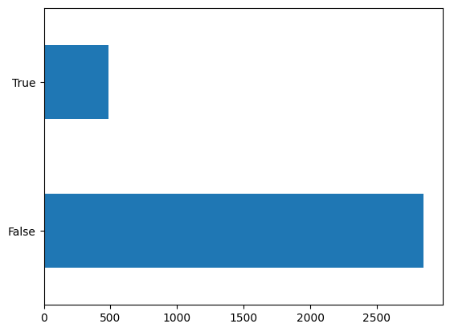

```python
df["churn"].value_counts().plot.barh();
```

```python
label_counts = df["churn"].value_counts()
print(label_counts)
```

```
False    2850
True      483
Name: churn, dtype: int64
```

**Here is the normal distribution, false are 2850 and true are 483**

```python
df["churn"].value_counts(normalize=True)
```

```
False    0.855086
True     0.144914
Name: churn, dtype: float64
```

# 6. What is the distribution of the feature, "international plan"? Calculate the probability of P(international plan = 'yes') and P(international plan = 'no').

```python
import numpy as np
distribution = df['international plan'].value_counts()
print(distribution)
print('The distribution of "international plan" being "NO" : ' + str(distribution[0])+ ' and YES: ' + str(distribution[1]) )
distribution_normalized= df['international plan'].value_counts(normalize='true')
print('The probability of international plan being NO = ' + str(np.round(distribution_normalized[0],4)*100)+'%')
print('The probability of international plan being NO = ' + str(np.round(distribution_normalized[1],3)*100)+'%')
```

```
no     3010
yes     323
Name: international plan, dtype: int64
The distribution of "international plan" being "NO" : 3010 and YES: 323
The probability of international plan being NO = 90.31%
The probability of international plan being NO = 9.700000000000001%
```

# 7. Assume you have devised a classification model that states that if "international plan" = 'no', then the customer will not churn (i.e., churn = False). Report the accuracy of this classification model on the given dataset.

```python
df['predict_no'] = (df['international plan'] == 'no')
df['churn_false'] = df['churn'].eq(False)
accuracy = df['predict_no'].eq(df['churn_false']).sum()/len(df)*100
print("The accuracy of model = ", "%.2f" % accuracy,'%')
```

```
The accuracy of model =  84.04 %
```

# 8. Calculate the following conditional probabilities:

- P(churn = True | international plan = `yes')
- P(churn = False | international plan = `yes')
- P(churn= True | international plan = `no')
- P(churn = False | international plan = `no')

Based on the probabilities computed above and those computed in parts 5 and 6, answer the following question using the Bayes theorem: "Given that a customer has churned (churn = True), what are the probabilities that the customer has opted/not-opted for the international plan? Similarly, given that the customer has not churned (churn = False), what are the probabilities that the customer has opted/not-opted for the international plan?"

```python
churn_true_ip_yes = pd.crosstab(
    df['churn'], df['international plan'],normalize = "columns",).iloc[1,1]
print("P(churn = True | international plan = `yes') =",churn_true_ip_yes)

churn_false_ip_yes = pd.crosstab(
    df['churn'], df['international plan'],normalize = "columns",).iloc[0,1]
print("P(churn = False | international plan = `yes') =", churn_false_ip_yes)

churn_true_ip_no = pd.crosstab(
    df['churn'], df['international plan'],normalize = "columns",).iloc[1,0]
print("P(churn = True | international plan = `no') =", churn_true_ip_no)


churn_false_ip_no = pd.crosstab(
    df['churn'], df['international plan'],normalize = "columns",).iloc[0,0]
print("P(churn = False | international plan = `no') =",churn_false_ip_no)

#Part -2
Int_pl_no = df['international plan'].value_counts(normalize=True)[0]

Int_pl_yes = df['international plan'].value_counts(normalize=True)[1]


churn_True = df['churn'].value_counts(normalize=True)[1]

churn_False = df['churn'].value_counts(normalize=True)[0]


no_true= (churn_true_ip_no * Int_pl_no)/churn_True
print("Probability of International plan is no and churn is true", no_true)

no_false = (churn_false_ip_no * Int_pl_no)/churn_False
print("Probability of International plan is no and churn is false", no_false)

yes_true = (churn_true_ip_yes * Int_pl_yes)/churn_True
print("Probability of International plan is yes and churn is true", yes_true)

no_false = (churn_false_ip_yes * Int_pl_yes)/churn_False
print("Probability of International plan is yes and churn is false", no_false)
```

```
P(churn = True | international plan = `yes') = 0.4241486068111455
P(churn = False | international plan = `yes') = 0.5758513931888545
P(churn = True | international plan = `no') = 0.11495016611295682
P(churn = False | international plan = `no') = 0.8850498338870432
Probability of International plan is no and churn is true 0.7163561076604554
Probability of International plan is no and churn is false 0.9347368421052631
Probability of International plan is yes and churn is true 0.2836438923395445
Probability of International plan is yes and churn is false 0.06526315789473684
```

# 9. Assume you have devised a classification model which states that if "international plan" = "yes" and the number of calls to the service center is greater than 3, then the customer will churn (i.e., "churn" = True). Report the accuracy of this classification model on the given dataset.

```python
df['predict_model'] = (df['international plan'] == 'yes' ) & (df['customer service calls'] > 3)
df['churn_true'] = df['churn'].eq(True)

accuracy = (df['predict_model'].eq(df['churn_true']).sum()/len(df))*100
print("Accuracy of classification model = ", "%.2f" % accuracy, "%")
```

```
Accuracy of classification model =  85.81 %
```

## 2 Problem 2 [23 points]

The files for this problem are under the Experiment 2 folder. Datasets to be used for experimentation: telecom churn.csv. Jupyter notebook to be used as a starting point: Decision Trees and kNN.ipynb. In this experiment we will apply and visualize decision trees and kNN, finetune their hyper-parameters and learn about k-fold cross validation. To visualize decision tree we need additional packages to be installed i.e., Graphviz and pydotplus (check the Anaconda.org page for instructions on how to install them using conda). Answer the following questions:

# 1. Consider training decision trees for the synthetic dataset involving two classes. How does the decision boundary look like when we overfit ( max depth 4 ) and underfit (max depth = 1) the decision tree on the given data? For both cases, paste the decision tree and the decision boundary from Jupyter notebook output.

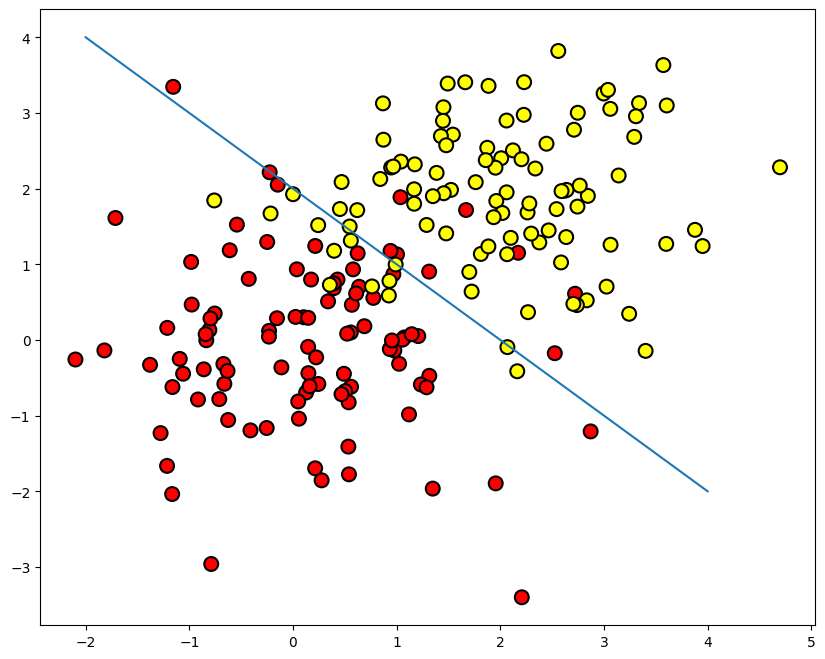

```python
import matplotlib.pyplot as plt
# code for the first class
np.random.seed(17)
training_data = np.random.normal(size=(100, 2))
training_labels = np.zeros(100)

# code for adding second class
training_data = np.r_[training_data, np.random.normal(size=(100, 2), loc=2)]
training_labels = np.r_[training_labels, np.ones(100)]

#code for plotting graph
plt.figure(figsize=(10,8))
plt.scatter(training_data[:, 0], training_data[:, 1], c=training_labels, s=100, cmap='autumn', edgecolors='black', linewidth=1.5);
plt.plot(range(-2,5), range(4,-3,-1));
```

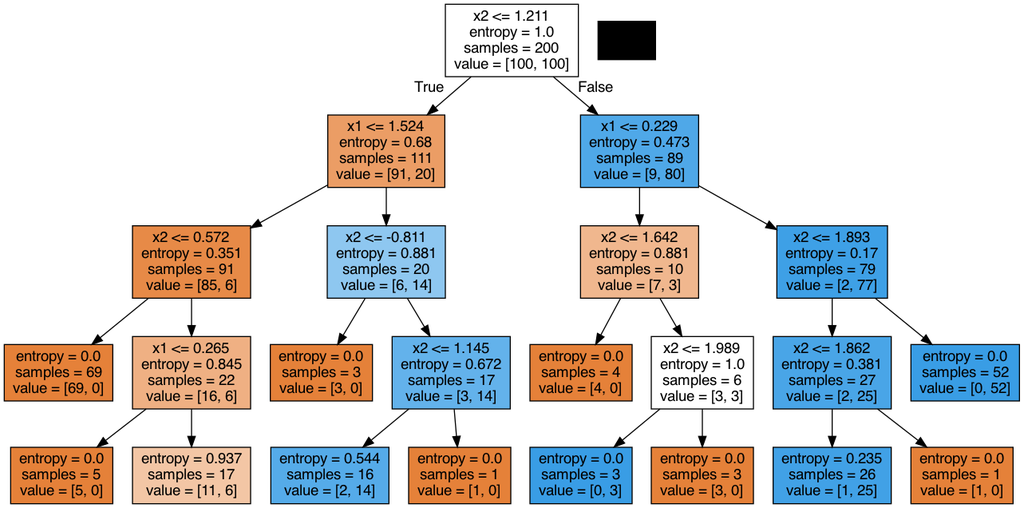

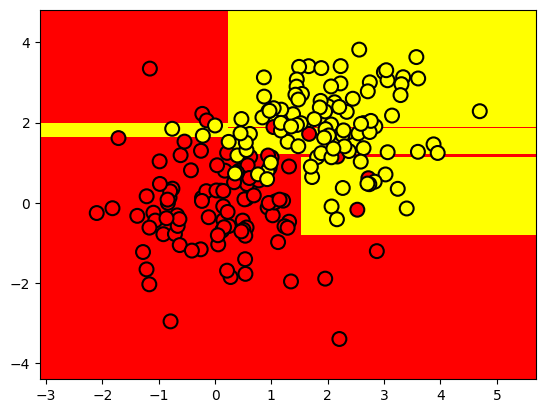

```python
from sklearn.tree import DecisionTreeClassifier
import pydotplus
from sklearn.tree import export_graphviz


def tree_graph_to_png(tree, feature_names, png_file_to_save):
    tree_str = export_graphviz(tree, feature_names=feature_names, filled=True, out_file=None)
    graph = pydotplus.graph_from_dot_data(tree_str)
    graph.write_png(png_file_to_save)


def get_grid(data):
    x_min, x_max = data[:, 0].min() - 1, data[:, 0].max() + 1
    y_min, y_max = data[:, 1].min() - 1, data[:, 1].max() + 1
    return np.meshgrid(np.arange(x_min, x_max, 0.01), np.arange(y_min, y_max, 0.01))

clf_tree = DecisionTreeClassifier(criterion='entropy',max_depth= 4, random_state=17)  # Max depth =4

# training the tree
clf_tree.fit(training_data, training_labels)

# some code to depict separating surface
xx, yy = get_grid(training_data)
predicted = clf_tree.predict(np.c_[xx.ravel(), yy.ravel()]).reshape(xx.shape)
plt.pcolormesh(xx, yy, predicted, cmap='autumn')
plt.scatter(training_data[:, 0], training_data[:, 1], c = training_labels, s=100, cmap='autumn', edgecolors='black', linewidth=1.5);


tree_graph_to_png(tree=clf_tree, feature_names=['x1', 'x2'], png_file_to_save = 'topic3_decision_tree1.png')

from IPython.display import Image
from IPython.core.display import HTML
PATH = "topic3_decision_tree1.png"
Image(filename = PATH , width=900, height=600)
```

**In the above, the max_depth = 4 classified the data into 12 types.**

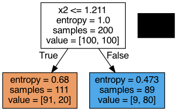

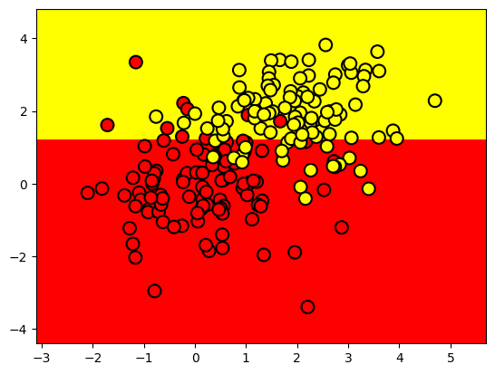

```python
from sklearn.tree import DecisionTreeClassifier
import pydotplus
from sklearn.tree import export_graphviz

def tree_graph_to_png(tree, feature_names, png_file_to_save):
    tree_str = export_graphviz(tree, feature_names=feature_names, filled=True, out_file=None)
    graph = pydotplus.graph_from_dot_data(tree_str)
    graph.write_png(png_file_to_save)


def get_grid(data):
    x_min, x_max = data[:, 0].min() - 1, data[:, 0].max() + 1
    y_min, y_max = data[:, 1].min() - 1, data[:, 1].max() + 1
    return np.meshgrid(np.arange(x_min, x_max, 0.01), np.arange(y_min, y_max, 0.01))

clf_tree = DecisionTreeClassifier(criterion='entropy',max_depth= 1, random_state=17)  # Max depth =1

# training the tree
clf_tree.fit(training_data, training_labels)

# some code to depict separating surface
xx, yy = get_grid(training_data)
predicted = clf_tree.predict(np.c_[xx.ravel(), yy.ravel()]).reshape(xx.shape)
plt.pcolormesh(xx, yy, predicted, cmap='autumn')
plt.scatter(training_data[:, 0], training_data[:, 1], c=training_labels, s=100, cmap='autumn', edgecolors='black', linewidth=1.5);

tree_graph_to_png(tree=clf_tree, feature_names=['x1', 'x2'], png_file_to_save='topic3_decision_tree1.png')

from IPython.display import Image
from IPython.core.display import HTML
PATH = "topic3_decision_tree1.png"
Image(filename = PATH , width=900, height=600)
```

**The above plot is for maxdepth=1 whereas max_depth = 1 classified upto 2**

# 2. Decision tree classifier sklearn.tree.DecisionT reeClassif ier has parameter "max depth" which defines the maximum depth of the tree. What happens if we don't specify any value for this parameter? Paste the decision tree and the decision boundary you will obtain for this default case from Jupyter notebook output.

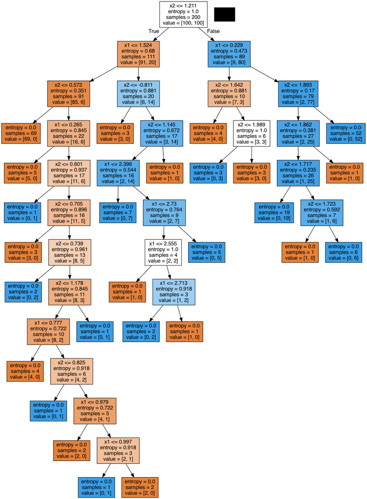

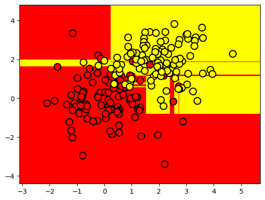

```python
from sklearn.tree import DecisionTreeClassifier
import pydotplus
from sklearn.tree import export_graphviz


def tree_graph_to_png(tree, feature_names, png_file_to_save):
    tree_str = export_graphviz(tree, feature_names=feature_names, filled=True, out_file=None)
    graph = pydotplus.graph_from_dot_data(tree_str)
    graph.write_png(png_file_to_save)


def get_grid(data):
    x_min, x_max = data[:, 0].min() - 1, data[:, 0].max() + 1
    y_min, y_max = data[:, 1].min() - 1, data[:, 1].max() + 1
    return np.meshgrid(np.arange(x_min, x_max, 0.01), np.arange(y_min, y_max, 0.01))

clf_tree = DecisionTreeClassifier(criterion='entropy', random_state=17)  # Max depth removed

# training the tree
clf_tree.fit(training_data, training_labels)

# some code to depict separating surface
xx, yy = get_grid(training_data)
predicted = clf_tree.predict(np.c_[xx.ravel(), yy.ravel()]).reshape(xx.shape)
plt.pcolormesh(xx, yy, predicted, cmap='autumn')
plt.scatter(training_data[:, 0], training_data[:, 1], c=training_labels, s=100, cmap='autumn', edgecolors='black', linewidth=1.5);


tree_graph_to_png(tree=clf_tree, feature_names=['x1', 'x2'], png_file_to_save='topic3_decision_tree1.png')

from IPython.display import Image
from IPython.core.display import HTML
PATH = "topic3_decision_tree1.png"
Image(filename = PATH , width=900, height=600)
```

**From the above plots it is observed if default value is mentioned, then nodes are expanded until all leaves are pure or until all leaves contain less than min_samples_split samples. In that case, the depth of the tree will be 12.**

# 3. For Bank Dataset, what are the 5 different age values that the decision tree used to construct the splits of the tree? What is the significance of these 5 values?

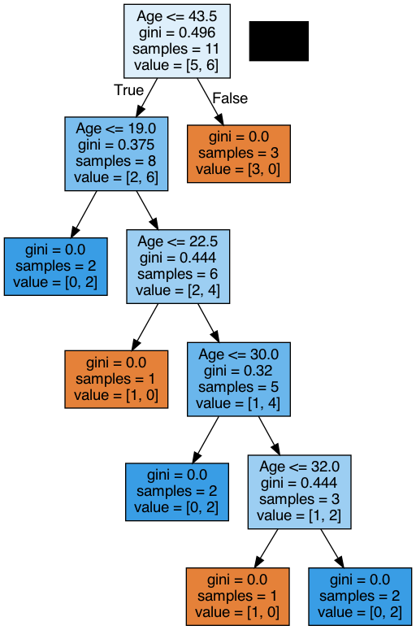

```python
data = pd.DataFrame({'Age': [17,64,18,20,38,49,55,25,29,31,33], 'Loan Default': [1,0,1,0,1,0,0,1,1,0,1]})
data.sort_values('Age')
data
age_tree = DecisionTreeClassifier(random_state=17)
age_tree.fit(data['Age'].values.reshape(-1, 1), data['Loan Default'].values)

tree_graph_to_png(age_tree, feature_names=['Age'], png_file_to_save='topic3_decision_tree2.png')

from IPython.display import Image
from IPython.core.display import HTML
PATH = "topic3_decision_tree2.png"
Image(filename = PATH , width=500, height=200)
```

**We see that the tree used the following 5 values to evaluate by age: 43.5, 19, 22.5, 30, and 32 years. These are exactly the mean values between the ages at which the target class "switches" from 1 to 0 or 0 to 1. The method for dealing features which are numeric in a decision tree is to sort its values in ascending and to check whether only those boundaries where the value of the target value changes.**

# 4. For the customer churn prediction task, we show that the accuracy of the decision tree is 94% when max depth is set to 5. What happens to accuracy when we leave the value of max depth to its default value? Explain the rise/fall of accuracy.

```python
df = pd.read_csv('./telecom_churn.csv')

df['international plan'] = pd.factorize(df['international plan'])[0]
df['voice mail plan'] = pd.factorize(df['voice mail plan'])[0]
df['churn'] = df['churn'].astype('int')
states = df['state']
y = df['churn']
df.drop(['state', 'churn','phone number'], axis=1, inplace=True)

from sklearn.model_selection import train_test_split, StratifiedKFold
from sklearn.neighbors import KNeighborsClassifier
from sklearn.preprocessing import StandardScaler

X_train, X_holdout, y_train, y_holdout = train_test_split(df.values, y, test_size=0.3,random_state=17)
tree = DecisionTreeClassifier( random_state = 17)
tree.fit(X_train, y_train)

from sklearn.metrics import accuracy_score

tree_pred = tree.predict(X_holdout)
print (f" Accuracy achieved = {accuracy_score(y_holdout, tree_pred)}")
```

```
 Accuracy achieved = 0.92
```

# 5. Given a dataset d, with n sample and m continuous features, what does Standard Scaler sklearn.preprocessing.StandardScaler do? Given dataset d = [[0, 0], [0, 0], [1, 1], [1, 1]], write down its scaler transformation.

```python
scaler = StandardScaler()
d  = [[0, 0], [0, 0], [1, 1], [1, 1]]
scaled_d = scaler.fit_transform(d)
scaled_d
```

```
array([[-1., -1.],
       [-1., -1.],
       [ 1.,  1.],
       [ 1.,  1.]])
```

**The above is the scalar transformation for give dataset**

**Scalar transformation is a mathematical operation that transforms a scalar value (i.e., a single number) into a different scalar value while preserving some of its properties. This operation is commonly used in signal processing, data analysis, and machine learning.**

# 6. How many decision trees do we have to construct if we have to search the two-parameter space, max depth[1-10] and max features[4-18]? If we consider 10-fold cross-validation with the above scenario, how many decision trees do we construct in total?

```python
from sklearn.model_selection import GridSearchCV, cross_val_score

tree_params = {'max_depth': range(1,11),'max_features': range(4,19)}

tree_grid = GridSearchCV(tree, tree_params, cv=10, n_jobs=-1, verbose=True) # 10 fold cross validation

tree_grid.fit(X_train, y_train)
```

```
Fitting 10 folds for each of 150 candidates, totalling 1500 fits
```

```
GridSearchCV(cv=10, estimator=DecisionTreeClassifier(random_state=17),
             n_jobs=-1,
             param_grid={'max_depth': range(1, 11),
                         'max_features': range(4, 19)},
             verbose=True)
```

# 7. For the customer churn prediction task, what is the best choice of k[1-10] in the k-nearest neighbor algorithm in the 10-fold cross-validation scenario?

```python
knn = KNeighborsClassifier(n_neighbors=5)
scaler = StandardScaler()
X_train_scaled = scaler.fit_transform(X_train)
X_holdout_scaled = scaler.transform(X_holdout)
knn.fit(X_train_scaled, y_train)

from sklearn.pipeline import Pipeline

knn_pipe = Pipeline([('scaler', StandardScaler()), ('knn', KNeighborsClassifier(n_jobs=-1))])

knn_params = {'knn__n_neighbors': range(1, 11)}

knn_grid = GridSearchCV(knn_pipe, knn_params, cv=10, n_jobs=-1, verbose=True)

knn_grid.fit(X_train, y_train)

knn_grid.best_params_, knn_grid.best_score_
```

```
Fitting 10 folds for each of 10 candidates, totalling 100 fits
```

```
({'knn__n_neighbors': 9}, 0.8868383404864092)
```

**The best choice of k is 9.**

# 8. For MNIST dataset, what was the accuracy of the decision tree [max depth = 5] and K-nearest neighbor [K = 10]? What were the best hyper-parameter values and test accuracy for decision trees when we used GridSearchCV with 5 fold cross-validation?

```python
from sklearn.datasets import load_digits

data = load_digits()
X, y = data.data, data.target

X[0,:].reshape([8,8])
```

```
array([[ 0.,  0.,  5., 13.,  9.,  1.,  0.,  0.],
       [ 0.,  0., 13., 15., 10., 15.,  5.,  0.],
       [ 0.,  3., 15.,  2.,  0., 11.,  8.,  0.],
       [ 0.,  4., 12.,  0.,  0.,  8.,  8.,  0.],
       [ 0.,  5.,  8.,  0.,  0.,  9.,  8.,  0.],
       [ 0.,  4., 11.,  0.,  1., 12.,  7.,  0.],
       [ 0.,  2., 14.,  5., 10., 12.,  0.,  0.],
       [ 0.,  0.,  6., 13., 10.,  0.,  0.,  0.]])
```

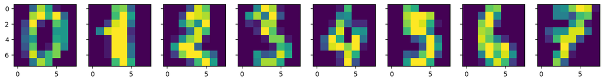

```python
f, axes = plt.subplots(1, 8, sharey=True, figsize=(16,6))
for i in range(8):
    axes[i].imshow(X[i,:].reshape([8,8]));
```

```python
X_train, X_holdout, y_train, y_holdout = train_test_split(X, y, test_size=0.3,random_state=17)

tree = DecisionTreeClassifier(max_depth=5, random_state=17)
knn_pipe = Pipeline([('scaler', StandardScaler()), ('knn', KNeighborsClassifier(n_neighbors=10))])

tree.fit(X_train, y_train)
knn_pipe.fit(X_train, y_train);
```

```python
tree_pred = tree.predict(X_holdout)
knn_pred = knn_pipe.predict(X_holdout)
print (f"K-Nearest neighbor accuracy is {accuracy_score(y_holdout, knn_pred)}")
print (f"Decision tree accuracy is {accuracy_score(y_holdout, tree_pred)}")
```

```
K-Nearest neighbor accuracy is 0.975925925925926
Decision tree accuracy is 0.6666666666666666
```

**The accuracy achieved for K nearest neighbor with n_neighbors 10 is 97.59% The accuracy achieved for decission tree with max_depth 5 is 66.67%**

```python
tree_params = {'max_depth': [1, 2, 3, 5, 10, 20, 25, 30, 40, 50, 64, 84,100], # Added 84, 100
               'max_features': [1, 2, 3, 5, 10, 20 ,30, 50, 64,84,100]}

tree_grid = GridSearchCV(tree, tree_params, cv=5, n_jobs=-1, verbose=True)


tree_grid.fit(X_train, y_train)
tree_grid.best_params_, tree_grid.best_score_
```

```
Fitting 5 folds for each of 143 candidates, totalling 715 fits
```

```
({'max_depth': 10, 'max_features': 50}, 0.8568203376968316)
```

```python
print (f"Decision tree accuracy is {accuracy_score(y_holdout,  tree_grid.predict(X_holdout))}")
```

```
Decision tree accuracy is 0.8425925925925926
```

```python
knn_grid = GridSearchCV(knn_pipe, knn_params, cv=5, n_jobs=-1, verbose=True)

knn_grid.fit(X_train, y_train)

knn_grid.best_params_, knn_grid.best_score_
```

```
Fitting 5 folds for each of 10 candidates, totalling 50 fits
```

```
({'knn__n_neighbors': 1}, 0.9689812179852021)
```

**Here now applying GridSearchCV with 5-fold cross-validation for the k neareest neigbhor, the accuracy achieved is 96.89%**

## 3 Problem 3 [10 points]

The files for this problem are under Experiment 3 folder. Datasets to be used for experimentation: spam.csv. Jupyter notebook to be used as starting point: Naive Bayes Spam.ipynb. The dataset contains 5,574 messages tagged according to ham (legitimate) or spam. In this experiment we will learn about text features, how to convert them in matrix form, and apply the Naive Bayes algorithm. Answer the following questions:

# 1. What is the distribution of the "label" class. Is it skewed?

```
ham     4825
spam     747
Name: label, dtype: int64
```

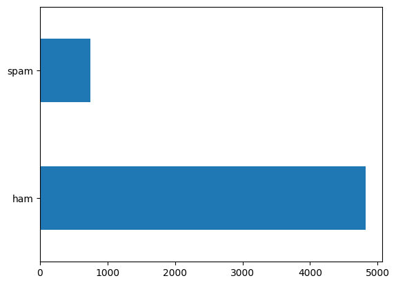

```python
import numpy as np # linear algebra
import pandas as pd # data processing, CSV file I/O (e.g. pd.read_csv)
import nltk
import pandas
df_spam = pd.read_csv('./spam.csv',encoding='latin-1')
df_spam.head()
dist=df_spam['label'].value_counts()
print(dist)
df_spam['label'].value_counts().plot.barh()
```

**Distribution of data is there are 4825 ham messages and 747 spam messages, by observing the graph above it can be observed that there is skewness in the data.**

# 2. How many unique values of SMS are there in the dataset? What is the SMS that occurred

most frequently and what is its frequency?

```python
df_spam['sms'].describe()
```

```
count                       5572
unique                      5169
top       Sorry, I'll call later
freq                          30
Name: sms, dtype: object
```

**There are total of 5572 sms Unique messsages are 5169 Most frequent sms is "Sorry, I'll call later" with a frequency of 30.**

# 3. What is the maximum and minimum length of SMS present in the dataset?

```python
df_spam['length'] = df_spam['sms'].apply(len)
df_spam['length'].describe()
```

```
count    5572.000000
mean       80.333094
std        59.842934
min         2.000000
25%        36.000000
50%        61.000000
75%       122.000000
max       910.000000
Name: length, dtype: float64
```

**Maximum length is 910 and shortest legth is 2, by using this:**

```python
df_spam.query('length==910')
```

|  | label | sms | length |
| --- | --- | --- | --- |
| 1084 | ham | For me the love should start with attraction.i... | 910 |

**This is the SMS with maximum length**

```python
df_spam.query('length==2')
```

|  | label | sms | length |
| --- | --- | --- | --- |
| 1924 | ham | Ok | 2 |
| 3049 | ham | Ok | 2 |
| 4496 | ham | Ok | 2 |
| 5357 | ham | Ok | 2 |

**This is the SMS with minimum length**

# 4. Plot the histogram of the length of SMS for both labels separately with bin size 5,

i.e. histogram of the length of all ham SMS and histogram of the length of all spam SMS. What can you say about the difference in SMS lengths across the two labels after examining the plots?

```python
df_ham= df_spam.query('label=="ham"')
df_ham.head()
```

|  | label | sms | length |
| --- | --- | --- | --- |
| 0 | ham | Go until jurong point, crazy.. Available only ... | 111 |
| 1 | ham | Ok lar... Joking wif u oni... | 29 |
| 3 | ham | U dun say so early hor... U c already then say... | 49 |
| 4 | ham | Nah I don't think he goes to usf, he lives aro... | 61 |
| 6 | ham | Even my brother is not like to speak with me. ... | 77 |

```python
df_sp= df_spam.query('label=="spam"')
df_sp.head()
```

|  | label | sms | length |
| --- | --- | --- | --- |
| 2 | spam | Free entry in 2 a wkly comp to win FA Cup fina... | 155 |
| 5 | spam | FreeMsg Hey there darling it's been 3 week's n... | 150 |
| 8 | spam | WINNER!! As a valued network customer you have... | 160 |
| 9 | spam | Had your mobile 11 months or more? U R entitle... | 154 |
| 11 | spam | SIX chances to win CASH! From 100 to 20,000 po... | 136 |

```
array([<Axes: title={'center': 'ham'}>, <Axes: title={'center': 'spam'}>],
      dtype=object)
```

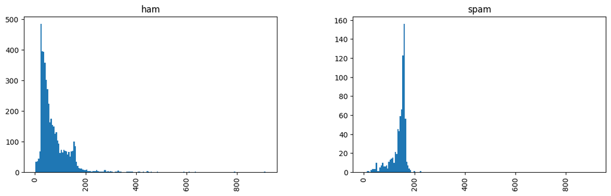

```python
import matplotlib.pyplot as plt

data = list(df_spam['length'])
binsize = 5
df_spam.hist(column='length', by='label', bins=range(min(data), max(data) + binsize, binsize),figsize=(14,4))
```

**The differences between the labels are: 1) The ham messages are skewed towards right, but the spam messages are skewed towards left. 2) Most of the messages are in between the length 0-200. 3) Spam messages are longer and ham messages are shorter.**

# 5. Using bag of words approach, convert documents = ['Hi, how are you?', 'Win money, win from home. Call now.', 'Hi., Call you now or tomorrow?'] to its document-term matrix. 6. Report accuracy, precision, recall and F1 score for the spam class after applying Naive Bayes algorithm.

```python
docs = ['Hi, how are you?', 'Win money, win from home. Call now.', 'Hi. Call you now or tomorrow?']
lower_case_docs = []
lower_case_docs = [d.lower() for d in docs]
print(lower_case_docs)
```

```
['hi, how are you?', 'win money, win from home. call now.', 'hi. call you now or tomorrow?']
```

```python
from sklearn.feature_extraction.text import CountVectorizer
count_vector = CountVectorizer()
```

```python
count_vector.fit(docs)
vectors=count_vector.vocabulary_.keys()
print(vectors)
```

```
dict_keys(['hi', 'how', 'are', 'you', 'win', 'money', 'from', 'home', 'call', 'now', 'or', 'tomorrow'])
```

```python
doc_arr = count_vector.transform(docs).toarray()
doc_arr
```

```
array([[1, 0, 0, 1, 0, 1, 0, 0, 0, 0, 0, 1],
       [0, 1, 1, 0, 1, 0, 1, 1, 0, 0, 2, 0],
       [0, 1, 0, 1, 0, 0, 0, 1, 1, 1, 0, 1]])
```

**Here is the matrix achieved**

```python
from sklearn.model_selection import train_test_split

X_train, X_test, y_train, y_test = train_test_split(df_spam['sms'], df_spam['label'],test_size=0.20, random_state=1)
```

```python
# Instantiate the CountVectorizer method
count_vector = CountVectorizer()

# Fit the training data and then return the matrix
training_data = count_vector.fit_transform(X_train)

# Transform testing data and return the matrix.
testing_data = count_vector.transform(X_test)
```

```python
print ('training data shape:', training_data.shape)
print ('testing data shape:',testing_data.shape)
```

```
training data shape: (4457, 7777)
testing data shape: (1115, 7777)
```

```python
from sklearn.naive_bayes import MultinomialNB
naive_bayes = MultinomialNB()
naive_bayes.fit(training_data,y_train)
```

```
MultinomialNB()
```

```python
predictions = naive_bayes.predict(testing_data)
```

```python
from sklearn.metrics import accuracy_score, precision_score, recall_score, f1_score
print("The scores are:")
print('Accuracy score: {}'.format(accuracy_score(y_test, predictions)))
print('Precision score: {}'.format(precision_score(y_test, predictions, pos_label = "spam")))
print('Recall score: {}'.format(recall_score(y_test, predictions, pos_label = "spam")))
print('F1 score: {}'.format(f1_score(y_test, predictions, pos_label = "spam")))
```

```
The scores are:
Accuracy score: 0.9847533632286996
Precision score: 0.9420289855072463
Recall score: 0.935251798561151
F1 score: 0.9386281588447652
```